# QiDigital_FitnessMarket

# Key takeways

**Wellness is a daily active pursuit**. Today’s generation, both young and old, are eating healthier and exercising more than ever before. Technology has enabled greater access to wellness information and has put health monitoring into the palm of their hands. As a result, today’s expenditure on everything fitness related has increased, especially among millennials.

For the Health Club Chains that we have studied, **going digital is not an option, it is an outermost necessity**. Communities, normally formed online, are increasingly becoming the top motivator for new gym enrollers. New comers as technology-based applications offering training programs or new take on traditional models as low-cost fitness club, have help reshape the industry. .

The average Analytics score is low. Together with the enormous spending on adds and other forms of promotion, may be a symptom for both **low conversion ratios, poor budget control and a general lack of control over consumers conversion journey**. Despite the intense competition and low switching costs, it is surprising to conclude that none of the studied brands have implemented to this date an automation strategy.

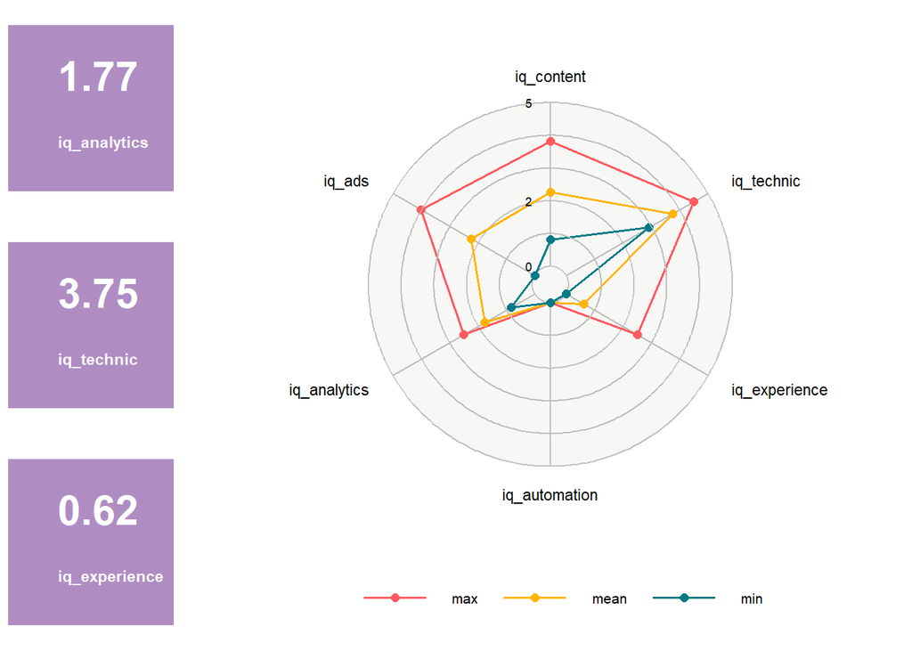

# Dimensions

## Ads & Analytics

Based on our research we concluded that brands rely solely on Web Analytics and basic Tag Management to manage their on-line presence. Only brand has a heat map tool implemented and only one had some events tagged. **This are clear outliers and the majority of the industry is passing by the opportunity to collect data and know better their users.**

## Automation

Automation is non-existent in the market. Not one of the brands studied in capable of creating automated conversations with prospects and/or client. In a very competitive service market such as this one, in which the barriers to switching are slim, it is surprising that companies have not invested in ways to build relationships with customers and leads outside of the physical space of the gyms themselves.

# Martech and Adtech

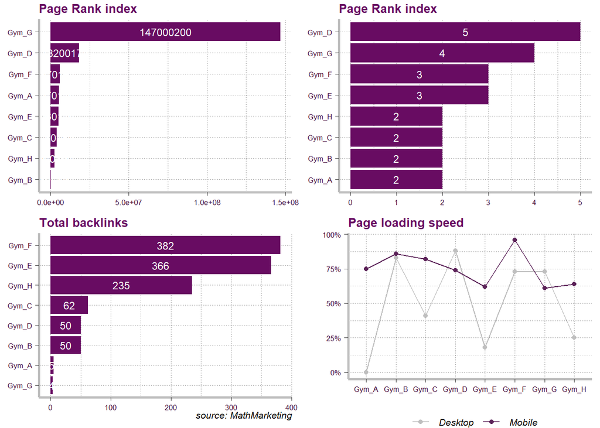

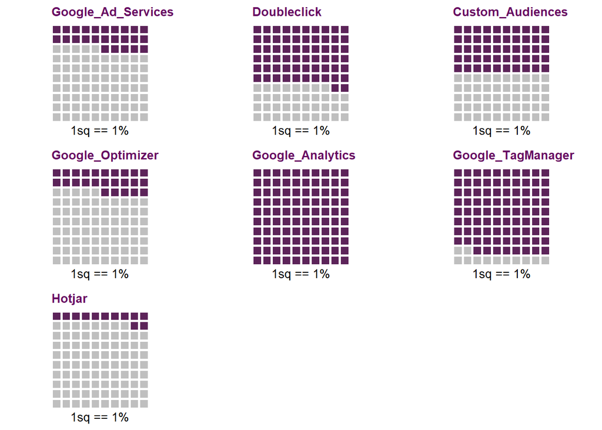

# Market summary and trends

The market for fitness gyms in Portugal has been facing an aggressive growth in the past years. Several large Groups, both national and international either opened or acquired brands and are expanding their networks. Research shows that about 18% of the Portuquese (15y+) went to a Gym/ health club in 2019. That number has been steadily growing since 2013.

This study was made we publicly available information from both financial statements, web pages and social network. All online information was collected by Math Marketing proprietary diagnosis tools off which only a fraction was used for this study. Only companies with operating in Portugal and with a total turnover above 3 Milion Euros in 2018 where included.2

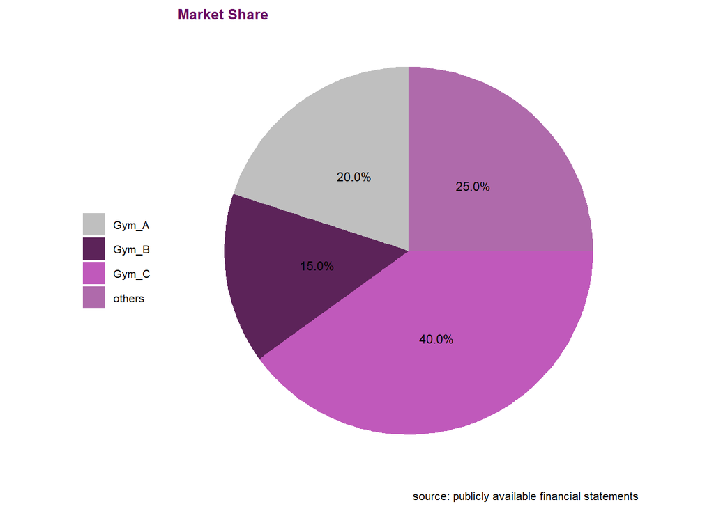